# 다양한 데이터 가져오기

트위터 데이터 과학

xwMOOC

Tidyverse Korea

2019-12-31

# 1 트위터 SNS

“트윗(tweet)”이란 말은 작은 새가 지저귀는 소리를 나타내는 영어 낱말로, [트위터(영어: Twitter)](https://www.twitter.com/)는 **소셜 네트워크 서비스(SNS)**이자 **마이크로블로그** 서비스로 볼 수 있다.

단문 메시지 서비스(SMS), 인스턴트 메신저, 전자 우편(e-mail) 등을 통해 “트윗(tweet)”를 전송할 수 있고, 글 한 편에 해당하는 단위는 트윗으로 140자가 한도가 된다. 한글이든 영문이든, 공백과 기호를 포함해 한 번에 140 까지 글자를 올릴 수 있다. 최근 [Donald J. Trump](https://twitter.com/realdonaldtrump) 대통령이 트워터를 적극적으로 정치에 활용하면서 다시 관심을 받고 있는 서비스이기도 하다.

## 1.1 트위터 통계 [^1]

월기준으로 3.3억 사용자가 있으며, 매일 5억개의 트윗이 있고, 사용자의 80%가 축복받은 1980~2000년 초반 출생한 밀레니얼 세대이며, 생중계 동안 트위터 광고는 11% 더 효과적으로 알려져 있으며 구매자의 40%는 트위터의 영향을 받는 것으로 조사된다.

1. Twitter has 145 million monetizable daily active users
2. Twitter’s U.S. user base is predicted to grow 0.3% in 2020
3. 30 million (or 20%) of Twitter’s daily users are American
4. 92% of the U.S. population is familiar with Twitter (even if they don’t use it)

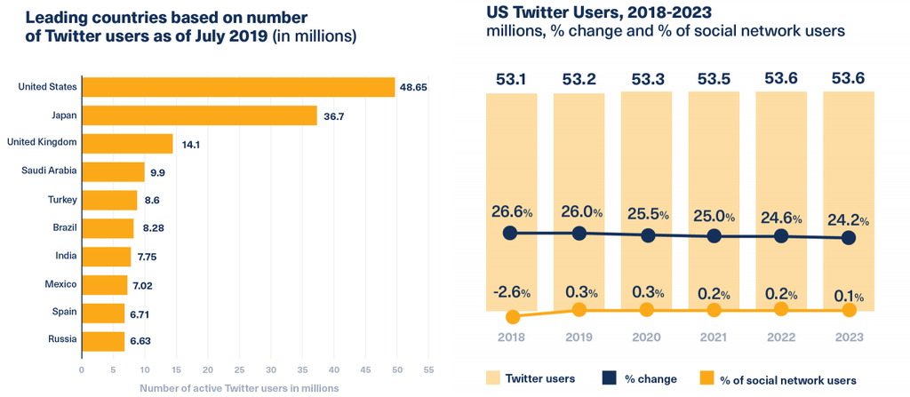

트위터 기초 통계

## 1.2 트위터 데이터

`rtweet` 팩키지 `stream_tweets()` 함수는 공개가 허락된 트윗 중에서 1%를 무작위로 가져오는데 기본설정으로 30초 동안 트윗을 추출한다.

## 1.3 트위터 활용분야

트위터 데이터를 분석해서 다양한 분야에 활용할 수 있다. 대표적으로 다음을 들 수 있다.

- 최신 유행 주제 발굴
- 고객 의견(customer opinion)
- 대중 감정 / 민심
- 브랜드/영화/연애인 영향력 범위
- 이벤트 탐지: 시위 혹은 전염병

# 2 트위터 계정 - `rtweet`

[`httpuv`: HTTP and WebSocket server package for R](https://github.com/rstudio/httpuv)를 기반한 [`rtweet`: R client for accessing Twitter’s REST and stream APIs](https://rtweet.info/) 팩키지로 천하통일 되었다고 볼 수 있다.

- `httpuv`: 웹브라우저를 통해 트위터 API를 인증할 수 있게 함. 따라서, 별도 트위터 개발자 페이지에 접속해서 인증키를 받아 이를 활용할 필요가 없어짐.
- `rtweet`: 트위터 API에서 데이터를 추출해서 분석이 가능한 형태의 데이터프레임으로 가공하여 반환시킴

설치는 `install.packages("rtweet")`으로 하면 쉽게 설치되고 별도 인증절차 없이 처음 브라우저 인증을 위한 과정만 추가된다. 이후 `search_tweets()` 등 함수를 사용해서 트위터 API에서 데이터를 수집하면 된다.

```r
# 0. 환경설정 -----
library(rtweet)  # install.packages("rtweet")
library(tidyverse)

tidyverse_tw <- search_tweets("#tidyverse", n = 100, include_rts = TRUE, lang = "en")
tidyverse_tw
```

```
# A tibble: 100 x 90
   user_id status_id created_at          screen_name text  source
   <chr>   <chr>     <dttm>              <chr>       <chr> <chr>
 1 176548… 12118861… 2019-12-31 05:45:48 ohebie      "I m… Twitt…
 2 101181… 12118436… 2019-12-31 02:57:00 rstatstweet "I m… rstat…
 3 101181… 12104558… 2019-12-27 07:02:21 rstatstweet geom… rstat…
 4 101181… 12104446… 2019-12-27 06:17:39 rstatstweet Usin… rstat…
 5 101181… 12105724… 2019-12-27 14:45:46 rstatstweet Chan… rstat…
 6 101181… 12105724… 2019-12-27 14:45:46 rstatstweet R- m… rstat…
 7 101181… 12105724… 2019-12-27 14:45:45 rstatstweet Noth… rstat…
 8 101181… 12106026… 2019-12-27 16:45:29 rstatstweet Comp… rstat…
 9 101181… 12116549… 2019-12-30 14:26:56 rstatstweet What… rstat…
10 101181… 12107115… 2019-12-27 23:58:28 rstatstweet Hey … rstat…
# … with 90 more rows, and 84 more variables: display_text_width <dbl>,
#   reply_to_status_id <chr>, reply_to_user_id <chr>,
#   reply_to_screen_name <chr>, is_quote <lgl>, is_retweet <lgl>,
#   favorite_count <int>, retweet_count <int>, quote_count <int>,
#   reply_count <int>, hashtags <list>, symbols <list>, urls_url <list>,
#   urls_t.co <list>, urls_expanded_url <list>, media_url <list>,
#   media_t.co <list>, media_expanded_url <list>, media_type <list>,
#   ext_media_url <list>, ext_media_t.co <list>,
#   ext_media_expanded_url <list>, ext_media_type <chr>,
#   mentions_user_id <list>, mentions_screen_name <list>, lang <chr>,
#   quoted_status_id <chr>, quoted_text <chr>, quoted_created_at <dttm>,
#   quoted_source <chr>, quoted_favorite_count <int>,
#   quoted_retweet_count <int>, quoted_user_id <chr>,
#   quoted_screen_name <chr>, quoted_name <chr>,
#   quoted_followers_count <int>, quoted_friends_count <int>,
#   quoted_statuses_count <int>, quoted_location <chr>,
#   quoted_description <chr>, quoted_verified <lgl>,
#   retweet_status_id <chr>, retweet_text <chr>,
#   retweet_created_at <dttm>, retweet_source <chr>,
#   retweet_favorite_count <int>, retweet_retweet_count <int>,
#   retweet_user_id <chr>, retweet_screen_name <chr>, retweet_name <chr>,
#   retweet_followers_count <int>, retweet_friends_count <int>,
#   retweet_statuses_count <int>, retweet_location <chr>,
#   retweet_description <chr>, retweet_verified <lgl>, place_url <chr>,
#   place_name <chr>, place_full_name <chr>, place_type <chr>,
#   country <chr>, country_code <chr>, geo_coords <list>,
#   coords_coords <list>, bbox_coords <list>, status_url <chr>,
#   name <chr>, location <chr>, description <chr>, url <chr>,
#   protected <lgl>, followers_count <int>, friends_count <int>,
#   listed_count <int>, statuses_count <int>, favourites_count <int>,
#   account_created_at <dttm>, verified <lgl>, profile_url <chr>,
#   profile_expanded_url <chr>, account_lang <lgl>,
#   profile_banner_url <chr>, profile_background_url <chr>,
#   profile_image_url <chr>
```

트위터 헬로월드를 찍게 되면 `get_trends()` 함수로 아무 생각없을 때 세상에 어떤 일이 일어나고 있는지 알아볼 수 있다. 어떤 주제가 뜨고 있고 어느 지역에서 그런 일이 일어나는지 파악하는데 도움이 된다. `search_tweets()`는 특정 해쉬태그 등 검색어를 넣어 관심 트윗을 얻어내는데 사용한다. `lookup_users()`는 트위터 계정에 대한 정보를 얻는데 도움을 얻을 수 있다.

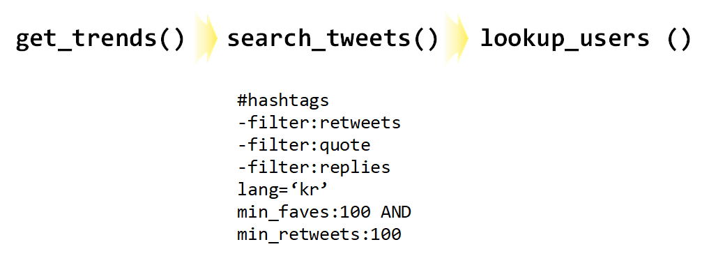

트위터 주요 키워드: `rtweet` 함수

## 2.1 트윗 검색 옵션

트윗 검색 함수에 검색어를 넣게 되면 모든 트윗을 다 가져온다. 마치 SQL 문의 `SELECT * FROM ...`와 같은 것이라 때로는 불필요한 정보가 포함되어 추후 다시 데이터 정제작업을 수행할 때가 있다. 이를 보완하고자 다양한 검색 옵션을 `rtweet` 팩키지에서 제공한다. 물론 트위터 API에서 따온 것이기는 하다.

먼저 활동성 통계량을 특정하여 트윗검색하는 방법을 살펴보자. `search_tweets()` 함수 내부에 검색어와 `min_faves`, `min_retweets`를 넣는다. `lang='en'`으로 언어도 영어로 한정한다.

- `#CloudComputing`
- `min_faves:10` `AND` `min_retweets:10`
- `lang='en'`

```r
cloud_option_twts <- search_tweets("#CloudComputing min_faves:10 AND min_retweets:10", lang='en')

cloud_option_twts %>%
  select(screen_name, favorite_count, retweet_count, text) %>%
  arrange(desc(favorite_count)) %>%
  DT::datatable()
```

|  | screen_name | favorite_count | retweet_count | text |
| --- | --- | --- | --- | --- |
| 1 | ThomasMaurer | 202 | 72 | How to Learn Microsoft Azure in 2020 🎉☁🎓 https://t.co/oXUbCT2g4p #Azure #2020 #Microsoft #CloudComputing #MSLearn #AzOps #AzDev #Career |
| 2 | antgrasso | 143 | 92 | Edge computing allows for the clear scoping of computing resources for optimal processing. @hackernoon via @antgrasso &amp;gt;&amp;gt;&amp;gt; #EdgeComputing #CloudComputing #IoT #IIoT https://t.co/72… |
| 3 | antgrasso | 105 | 92 | To grow cloud computing spending, technology and service providers need to prioritize an organization’s cloud ambitions over countrywide priorities. Source &amp;gt; https://t.co/dDo3Px4ZS5 @Gartner_in… |
| 4 | antgrasso | 103 | 70 | Process and analyze your distributed data at the edge by redefining your network as software platform. Link &amp;gt;&amp;gt; https://t.co/By8kTA0kcO @smeganatha via @antgrasso #Microservices #CloudCom… |
| 5 | holo_of | 101 | 40 | Most #Startups will proudly release their #App. #Holochain is releasing an #App store! That should give you an idea of how big this is actually going to be and why #VentureCapital is watching. #innova… |
| 6 | antgrasso | 96 | 65 | Multi-access Edge Computing #MEC : telcos should explore what could be viable business models to support the many potential MEC use cases. Link &amp;gt;&amp;gt; https://t.co/LARE9q7rLL @Inteliot @STLP… |
| 7 | gp_pulipaka | 83 | 71 | The Books To Start You On #DeepLearning. #BigData #Analytics #DataScience #AI #MachineLearning #IoT #IIoT #PyTorch #Python #RStats #TensorFlow #Java #JavaScript #ReactJS #GoLang #CloudComputing #Serve… |
| 8 | holo_of | 82 | 32 | This is why #Holofuel can reach $1 as it's creator stated. The hosting price will eventually reach market prices for #CloudComputing or be sligtly under. #Holochain is #GreenTech faster, more secure a… |
| 9 | antgrasso | 81 | 56 | Multi-cloud Interoperability Building Blocks. https://t.co/W0nWAAGENe @EverestGroup via @antgrasso #CloudComputing #MultiCloud #DigitalTransformation https://t.co/yyC3RHyQzx |
| 10 | antgrasso | 80 | 60 | Interoperable Multi-cloud: The Foundation for Transformation. https://t.co/ZGQ7Yu6doA @EverestGroup via @antgrasso #CloudComputing #MultiCloud #DigitalTransformation https://t.co/4s6L4qEajV |

[output cut: 90 more lines]

이외에도 `retweets`, `quote`, `replies`를 제거한 트윗을 얻기 위해 `filter:` 선택옵션을 추가한다.

- Exclude retweets via “-filter:retweets”
- Exclude quotes via “-filter:quote”
- Exclude replies via “-filter:replies”
- Filter (return only) verified via “filter:verified”
- Exclude verified via “-filter:verified”
- Get everything (firehose for free) via “-filter:verified OR filter:verified”
- Filter (return only) tweets with links to news articles via “filter:news”
- Filter (return only) tweets with media “filter:media”

```r
cloud_filter_twts <- search_tweets("#CloudComputing
                                   min_faves:10 AND min_retweets:10
                                   -filter:retweets
                                   -filter:quote
                                   -filter:replies",
                                   lang='en')

cloud_filter_twts %>%
  select(screen_name, favorite_count, retweet_count, text) %>%
  arrange(desc(favorite_count)) %>%
  DT::datatable()
```

|  | screen_name | favorite_count | retweet_count | text |
| --- | --- | --- | --- | --- |
| 1 | ThomasMaurer | 202 | 72 | How to Learn Microsoft Azure in 2020 🎉☁🎓 https://t.co/oXUbCT2g4p #Azure #2020 #Microsoft #CloudComputing #MSLearn #AzOps #AzDev #Career |
| 2 | antgrasso | 143 | 92 | Edge computing allows for the clear scoping of computing resources for optimal processing. @hackernoon via @antgrasso &amp;gt;&amp;gt;&amp;gt; #EdgeComputing #CloudComputing #IoT #IIoT https://t.co/72… |
| 3 | antgrasso | 105 | 92 | To grow cloud computing spending, technology and service providers need to prioritize an organization’s cloud ambitions over countrywide priorities. Source &amp;gt; https://t.co/dDo3Px4ZS5 @Gartner_in… |
| 4 | antgrasso | 103 | 70 | Process and analyze your distributed data at the edge by redefining your network as software platform. Link &amp;gt;&amp;gt; https://t.co/By8kTA0kcO @smeganatha via @antgrasso #Microservices #CloudCom… |
| 5 | holo_of | 101 | 40 | Most #Startups will proudly release their #App. #Holochain is releasing an #App store! That should give you an idea of how big this is actually going to be and why #VentureCapital is watching. #innova… |
| 6 | antgrasso | 96 | 65 | Multi-access Edge Computing #MEC : telcos should explore what could be viable business models to support the many potential MEC use cases. Link &amp;gt;&amp;gt; https://t.co/LARE9q7rLL @Inteliot @STLP… |
| 7 | gp_pulipaka | 83 | 71 | The Books To Start You On #DeepLearning. #BigData #Analytics #DataScience #AI #MachineLearning #IoT #IIoT #PyTorch #Python #RStats #TensorFlow #Java #JavaScript #ReactJS #GoLang #CloudComputing #Serve… |
| 8 | holo_of | 82 | 32 | This is why #Holofuel can reach $1 as it's creator stated. The hosting price will eventually reach market prices for #CloudComputing or be sligtly under. #Holochain is #GreenTech faster, more secure a… |
| 9 | antgrasso | 81 | 56 | Multi-cloud Interoperability Building Blocks. https://t.co/W0nWAAGENe @EverestGroup via @antgrasso #CloudComputing #MultiCloud #DigitalTransformation https://t.co/yyC3RHyQzx |
| 10 | antgrasso | 80 | 60 | Interoperable Multi-cloud: The Foundation for Transformation. https://t.co/ZGQ7Yu6doA @EverestGroup via @antgrasso #CloudComputing #MultiCloud #DigitalTransformation https://t.co/4s6L4qEajV |

[output cut: 90 more lines]

# 3 최신 유행 주제

가장 먼저 특정 지역에 가장 유행하는 주제가 무엇인지 찾아보자. 이를 **트위터 트렌드(twitter trend)**라고 흔히 부른다. `get_trends()` 함수를 사용하게 되면 전세계 트윗을 해쉬태그(hashtag), 키워드, 이벤트, 지역 등을 분석해서 최신 유행하는 주제를 파악할 수 있다.

```r
trend_topics <- get_trends()
trend_topics %>%
  DT::datatable()
```

|  | trend | url | promoted_content | query | tweet_volume | place | woeid | as_of | created_at |
| --- | --- | --- | --- | --- | --- | --- | --- | --- | --- |
| 1 | #ももいろ歌合戦 | http://twitter.com/search?q=%23%E3%82%82%E3%82%82%E3%81%84%E3%82%8D%E6%AD%8C%E5%90%88%E6%88%A6 |  | %23%E3%82%82%E3%82%82%E3%81%84%E3%82%8D%E6%AD%8C%E5%90%88%E6%88%A6 | 54872 | Worldwide | 1 | 2019-12-30T23:56:11Z | 2019-12-30T23:50:16Z |
| 2 | #MutluYıllar | http://twitter.com/search?q=%23MutluY%C4%B1llar |  | %23MutluY%C4%B1llar |  | Worldwide | 1 | 2019-12-30T23:56:11Z | 2019-12-30T23:50:16Z |
| 3 | ガキ使 | http://twitter.com/search?q=%E3%82%AC%E3%82%AD%E4%BD%BF |  | %E3%82%AC%E3%82%AD%E4%BD%BF | 48100 | Worldwide | 1 | 2019-12-30T23:56:11Z | 2019-12-30T23:50:16Z |
| 4 | #MüslümanNoelKutlamaz | http://twitter.com/search?q=%23M%C3%BCsl%C3%BCmanNoelKutlamaz |  | %23M%C3%BCsl%C3%BCmanNoelKutlamaz |  | Worldwide | 1 | 2019-12-30T23:56:11Z | 2019-12-30T23:50:16Z |
| 5 | 年越しそば | http://twitter.com/search?q=%E5%B9%B4%E8%B6%8A%E3%81%97%E3%81%9D%E3%81%B0 |  | %E5%B9%B4%E8%B6%8A%E3%81%97%E3%81%9D%E3%81%B0 | 75509 | Worldwide | 1 | 2019-12-30T23:56:11Z | 2019-12-30T23:50:16Z |
| 6 | #happynewyear2020 | http://twitter.com/search?q=%23happynewyear2020 |  | %23happynewyear2020 | 51590 | Worldwide | 1 | 2019-12-30T23:56:11Z | 2019-12-30T23:50:16Z |
| 7 | #KPopisCringe | http://twitter.com/search?q=%23KPopisCringe |  | %23KPopisCringe | 76763 | Worldwide | 1 | 2019-12-30T23:56:11Z | 2019-12-30T23:50:16Z |
| 8 | 年越し蕎麦 | http://twitter.com/search?q=%E5%B9%B4%E8%B6%8A%E3%81%97%E8%95%8E%E9%BA%A6 |  | %E5%B9%B4%E8%B6%8A%E3%81%97%E8%95%8E%E9%BA%A6 | 51785 | Worldwide | 1 | 2019-12-30T23:56:11Z | 2019-12-30T23:50:16Z |
| 9 | Voyage | http://twitter.com/search?q=Voyage |  | Voyage | 202933 | Worldwide | 1 | 2019-12-30T23:56:11Z | 2019-12-30T23:50:16Z |
| 10 | 描き納め | http://twitter.com/search?q=%E6%8F%8F%E3%81%8D%E7%B4%8D%E3%82%81 |  | %E6%8F%8F%E3%81%8D%E7%B4%8D%E3%82%81 | 165854 | Worldwide | 1 | 2019-12-30T23:56:11Z | 2019-12-30T23:50:16Z |

[output cut: 40 more lines]

`trends_available()` 함수를 사용하게 되면 추출가능한 트렌드에 대한 정보를 얻을 수 있는데 `countryCode`를 한국(“KR”)으로 특정해서 대한민국과 연관된 트렌드만 파악할 수 있도록 한다.

```r
availabel_trends <- trends_available()

availabel_trends %>%
  filter(countryCode == "KR")
```

```
# A tibble: 15 x 8
   name   url          parentid country  woeid countryCode  code place_type
   <chr>  <chr>           <int> <chr>    <int> <chr>       <int> <chr>
 1 Goyang http://wher… 23424868 Korea   1.13e6 KR              7 Town
 2 Yongin http://wher… 23424868 Korea   1.13e6 KR              7 Town
 3 Ansan  http://wher… 23424868 Korea   1.13e6 KR              7 Town
 4 Buche… http://wher… 23424868 Korea   1.13e6 KR              7 Town
 5 Busan  http://wher… 23424868 Korea   1.13e6 KR              7 Town
 6 Chang… http://wher… 23424868 Korea   1.13e6 KR              7 Town
 7 Daegu  http://wher… 23424868 Korea   1.13e6 KR              7 Town
 8 Gwang… http://wher… 23424868 Korea   1.13e6 KR              7 Town
 9 Inche… http://wher… 23424868 Korea   1.13e6 KR              7 Town
10 Seong… http://wher… 23424868 Korea   1.13e6 KR              7 Town
11 Suwon  http://wher… 23424868 Korea   1.13e6 KR              7 Town
12 Ulsan  http://wher… 23424868 Korea   1.13e6 KR              7 Town
13 Seoul  http://wher… 23424868 Korea   1.13e6 KR              7 Town
14 Daeje… http://wher… 23424868 Korea   2.35e6 KR              7 Town
15 Korea  http://wher…        1 Korea   2.34e7 KR             12 Country
```

## 3.1 대한민국 유행 주제

```r
library(glue)

korea_woeid <- availabel_trends %>%
  filter(countryCode == "KR", woeid == 23424868) %>%
  select(woeid) %>%
  pull(woeid)

korea_trend <- get_trends(korea_woeid)

korea_trend %>%
  group_by(trend) %>%
  summarise(mean_tweet_volume = mean(tweet_volume, na.rm = TRUE)) %>%
  arrange(desc(mean_tweet_volume))
```

```
# A tibble: 50 x 2
   trend              mean_tweet_volume
   <chr>                          <dbl>
 1 파트라                         24213
 2 #별명만들기                      NaN
 3 #카이_스포일러                   NaN
 4 강원기                           NaN
 5 곰표패딩                         NaN
 6 국민의 신뢰                      NaN
 7 국민의 정치적 선택               NaN
 8 그란디스                         NaN
 9 너무나 옹색                      NaN
10 뇌물수수                         NaN
# … with 40 more rows
```

```r
korea_trend %>%
  write_rds(glue("data/kr_trend_{Sys.Date()}.rds"))
```

궁금해서 twitter에 검색을 해보니… 레드벨벳 웬디가 SBS ‘가요대전’ 추락사고가 발생되서 팬들이 SBS를 질타하는 내용임을 확인할 수 있다.

> 사고 발생 후 4일이 흘렀는데 아직도 이게 안됩니까?  
> 사고 경위, 사고 발생 원인과 책임 소재 규명, 총책임자의 사과, 구체적인 피해 보상계획, 사고 재발 방지를 위한 대책이 포함된 정식 사과문. [#SBS는_책임져라](https://twitter.com/hashtag/SBS%EB%8A%94_%EC%B1%85%EC%9E%84%EC%A0%B8%EB%9D%BC?src=hash&ref_src=twsrc%5Etfw)[#TakeResponsibilitySBS](https://twitter.com/hashtag/TakeResponsibilitySBS?src=hash&ref_src=twsrc%5Etfw)[@SBSNOW](https://twitter.com/SBSNOW?ref_src=twsrc%5Etfw)[#WaitingForWendy](https://twitter.com/hashtag/WaitingForWendy?src=hash&ref_src=twsrc%5Etfw)

> — 린넨커튼&벨벳로프 (@dj_netrider) [December 28, 2019](https://twitter.com/dj_netrider/status/1210844831963996160?ref_src=twsrc%5Etfw)

# 4 클라우드 인기 시계열

클라우드 경쟁이 치열하다. 아마존 AWS를 비롯하여 마이크로소프트 Azure, Google Cloud, IBM 그리고 최근에는 알리바바가 폭풍성장을 하고 있다. [CIODIVE, “AWS to encounter IaaS market ‘erosion’ as contenders mature”](https://www.ciodive.com/news/iaas-Azure-AWS-Google-Cloud-Alibaba/559716/) 기사 내용과 비교하여 한국에서 트윗되고 있는 내용과 비교해보자.

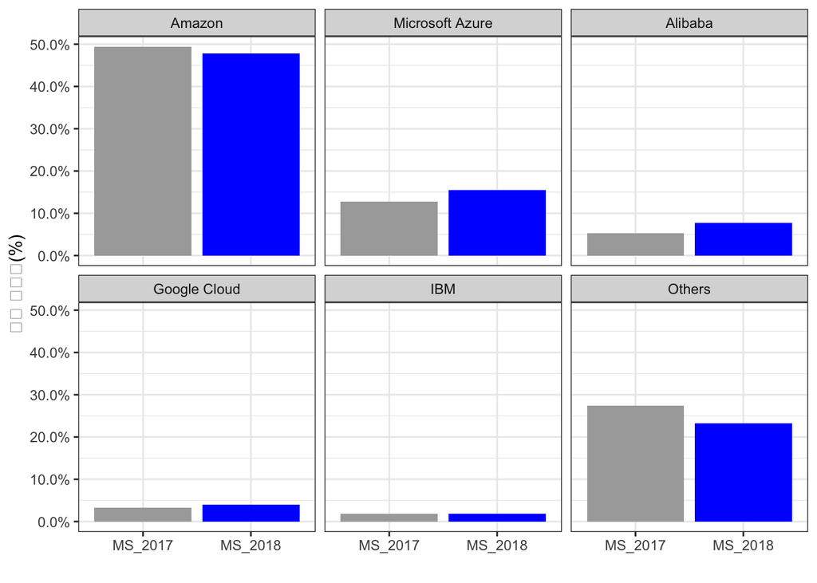

```r
library(rvest)

cloud_url <- "https://www.ciodive.com/news/iaas-Azure-AWS-Google-Cloud-Alibaba/559716/"

cloud_df <- cloud_url %>%
  read_html() %>%
  html_nodes(xpath='//*[@id="main-content"]/article/div[2]/div[2]/div/div[1]/div[3]/table') %>%
  html_table() %>%
  .[[1]]

cloud_df %>%
  select(-`Growth, 2017-2018`) %>%
  pivot_longer(cols=contains("Market")) %>%
  mutate(value = parse_number(value) / 100) %>%
  mutate(name = str_replace(name, "Market share, ", "MS_")) %>%
  mutate(Company = factor(Company, levels = c("Amazon", "Microsoft Azure", "Alibaba", "Google Cloud","IBM", "Others"))) %>%
  ggplot(aes(x=name, y=value, fill=name)) +
    geom_col() +
    # scale_y_continuous(labels = scales::label_percent(accuracy = 1)) +
    scale_y_continuous(labels = scales::percent) +
    facet_wrap(~Company) +
    labs(x="", y="시장 점유율(%)") +
    scale_fill_manual(values=c("darkgray", "blue")) +
    theme_bw() +
    theme(legend.position = "none")
```

`lang="ko"`로 클라우드 3사를 비교하는 것은 트윗이 너무 적어서 포기함.

```r
aws_tw <- search_tweets("#AWS", n = 18000, include_rts = FALSE, lang="ko")
azure_tw <- search_tweets("#Azure", n = 18000, include_rts = FALSE, lang="ko")
gcp_tw <- search_tweets("#GCP", n = 18000, include_rts = FALSE, lang="ko")
alibaba_tw <- search_tweets("#AlibabaCloud", n = 18000, include_rts = FALSE, lang="ko")
```

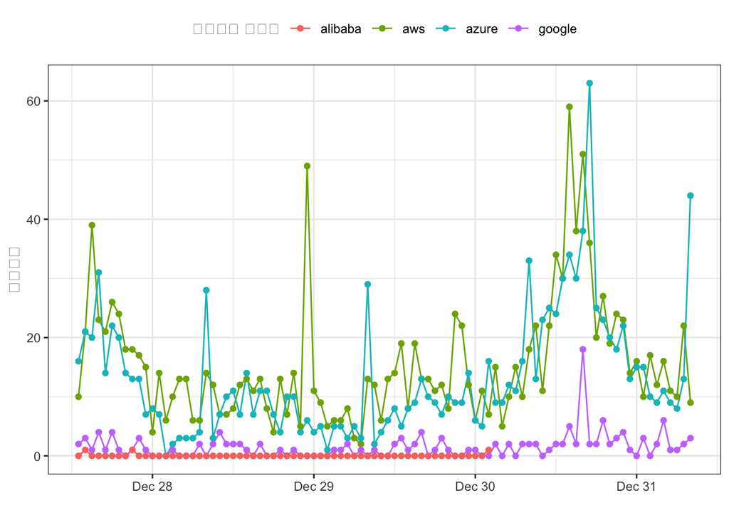

```r
aws_tw <- search_tweets("#AWS", n = 1800, include_rts = FALSE)
azure_tw <- search_tweets("#Azure", n = 1800, include_rts = FALSE)
gcp_tw <- search_tweets("#googlecloud", n = 1800, include_rts = FALSE)
alibaba_tw <- search_tweets("#AlibabaCloud", n = 1800, include_rts = FALSE)

aws_ts_df <- ts_data(aws_tw, by="hours")
azure_ts_tw <- ts_data(azure_tw, by="hours")
gcp_ts_tw <- ts_data(gcp_tw, by="hours")
alibaba_ts_tw <- ts_data(alibaba_tw, by="hours")

aws_ts_df %>%
  rename(aws=n) %>%
  left_join(azure_ts_tw, by="time") %>%
  rename(azure=n) %>%
  left_join(gcp_ts_tw, by="time") %>%
  rename(google=n) %>%
  left_join(alibaba_ts_tw, by="time") %>%
  rename(alibaba=n) %>%
  pivot_longer(-time) %>%
  ggplot(aes(x=time, y=value, color=name, group=name)) +
    geom_line() +
    geom_point() +
    labs(x="", y="트윗횟수", color="클라우드 서비스") +
    theme_bw() +
    theme(legend.position = "top")
```

# 5 활동성 - `#CloudComputing`

`#CloudComputing`을 가장 많이 언급하는 트윗 사용자를 찾아보자. 이를 위해서 먼저 `search_tweets()` 함수로 해쉬태그 “#CloudComputing”을 넣고 `screen_name`을 기준으로 트윗횟수를 세어본다.

```r
cloud_twts <- search_tweets("#CloudComputing", n=1800)

cloud_twts %>%
  count(screen_name, name="트윗수", sort=TRUE)
```

```
# A tibble: 815 x 2
   screen_name     트윗수
   <chr>            <int>
 1 LlnuxBot            69
 2 IAM__Network        65
 3 byte_code_          53
 4 ServerlessFan       32
 5 chidambara09        29
 6 rstatstweet         25
 7 cybersec_feeds      23
 8 reversepython       23
 9 DeepSingularity     20
10 gp_pulipaka         20
# … with 805 more rows
```

`#CloudComputing` 해쉬태그 상위 10명을 추출하여 `lookup_users()` 함수로 활동성과 관련된 지표를 추출한다.

- status
- followers
- friends
- favourites

```r
top_users <- cloud_twts %>%
  count(screen_name, name="트윗수", sort=TRUE) %>%
  top_n(10, wt=트윗수) %>%
  pull(screen_name)

lookup_users(top_users) %>%
  # select(screen_name, contains("_count")) %>%
  select(screen_name, statuses_count, followers_count, friends_count, favourites_count)
```

```
# A tibble: 11 x 5
   screen_name statuses_count followers_count friends_count
   <chr>                <int>           <int>         <int>
 1 LlnuxBot             63124             584             1
 2 IAM__Netwo…         500184           16198         13156
 3 byte_code_           16453             315            21
 4 Serverless…         181780            2586             6
 5 chidambara…         842320            5889            13
 6 rstatstweet         127973            4966            25
 7 cybersec_f…         497065            5364             0
 8 reversepyt…          10281             276            16
 9 DeepSingul…          39179            4885             4
10 gp_pulipaka          51829           73664         27663
11 RaymondWSA…          15353              81             2
# … with 1 more variable: favourites_count <int>
```

트윗 유저 상기 활동성 지표를 `ggplot`으로 시각화하여 각 사용자별 특성을 직관적으로 파악할 수 있도록 한다.

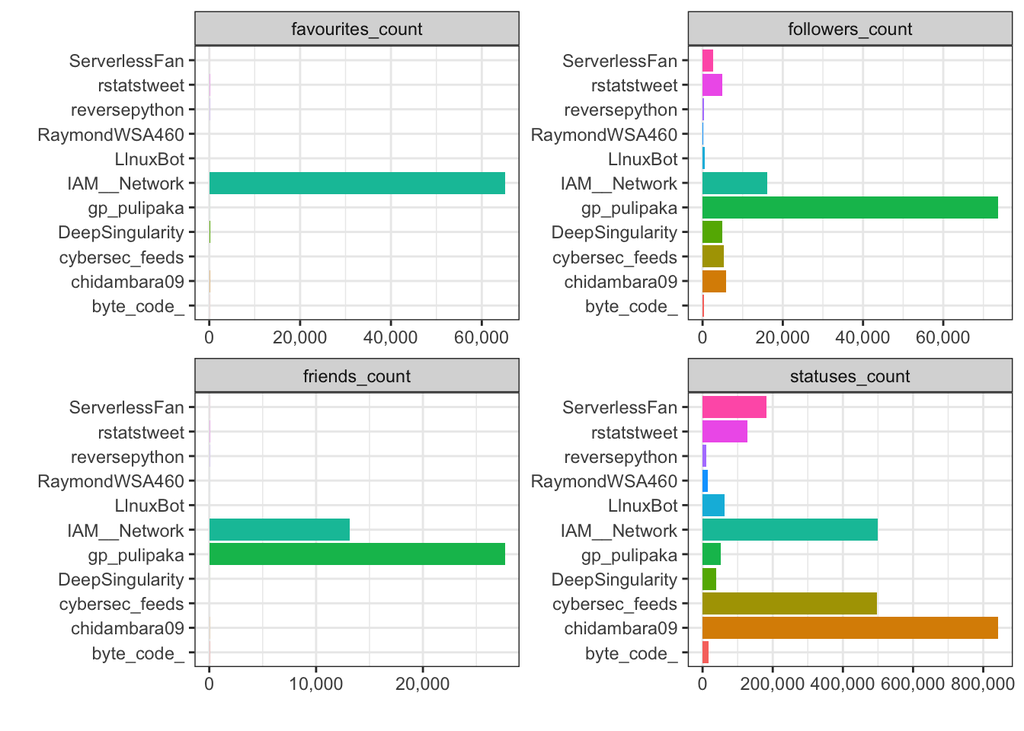

```r
lookup_users(top_users) %>%
  select(screen_name, statuses_count, followers_count, friends_count, favourites_count) %>%
  pivot_longer(-screen_name) %>%
  ggplot(aes(x=screen_name, y=value, fill=screen_name)) +
    geom_col() +
    coord_flip() +
    scale_y_continuous(labels=scales::comma) +
    facet_wrap(~name, scales = "free") +
    labs(x="", y="") +
    theme_bw() +
    theme(legend.position = "none")
```

# 6 네트워크 분석

`#CloudComputing`관련 트윗 검색어를 넣어 `include_rts = TRUE` 리트윗을 추적해보자. 이를 위해서 먼저 `screen_name`, `retweet_screen_name`을 넣어 엣지리스트 데이터프레임을 만든다. 그리고 나서, `graph_from_data_frame()` 함수로 데이터프레임을 네트워크 자료형으로 변환시킨다.

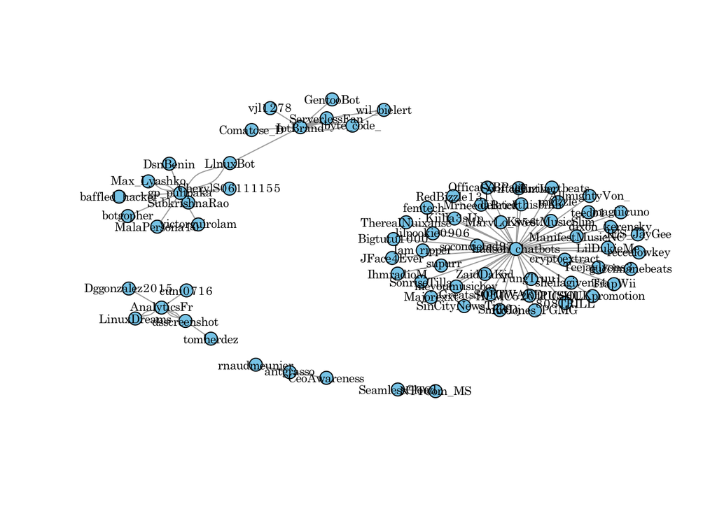

```r
library(igraph)

cc_twts <- search_tweets("#CloudComputing ", n=100, include_rts = TRUE)

cc_twts_edgelist <- cc_twts %>%
  select(screen_name, retweet_screen_name, followers_count) %>%
  filter(complete.cases(.))

cc_twts_nw <- graph_from_data_frame(cc_twts_edgelist, directed = TRUE)

plot(cc_twts_nw,
     asp = 9/16,
     vertex.size = 5,
     vertex.color = "skyblue",
     edge.arrow.size = 0.1,
     edge.color = "darkgray",
     vertex.label.cex = 0.7,
     vertex.label.color = "black")
```

네트워크 분석의 중요한 내용으로 중심성(centrality) 등 기술통계량을 추출하여 고급 분석을 이어간다. 이에 대한 자세한 사항은 [데이터 과학 – 네트워크](https://statkclee.github.io/network/)를 참조한다.

# 7 공간정보

`#volcano`관련 트윗 검색어를 어디에서 많이 하는지 공간정보가 포함되어 있는 경우 이를 반영시킨다. `lat_lng()` 함수를 사용하면 “coords_coords”, “bbox_coords”, “geo_coords” 칼럼을 참고해서 위경도 정보를 추출한다. 이를 `leaflet` 팩키지를 활용하여 공간정보 시각화를 한다.

```r
library(leaflet)

# 트윗 가져오기
geo_twts <- search_tweets("#volcano ", n=1000, include_rts = TRUE)

geo_twts_df <- lat_lng(geo_twts) %>%
  select(screen_name, text, lng, lat) %>%
  filter(!is.na(lng))


geo_twts_df %>%
  leaflet() %>%
    addProviderTiles(providers$OpenStreetMap) %>%
    addMarkers(lng=~lng, lat=~lat, clusterOptions = markerClusterOptions(),
                     popup = ~ as.character(paste0("<strong>", paste0("유저명: ",`screen_name`), "</strong><br>",
                                                   "-----------------------------------------------------------<br>",
                                                   "&middot; 트윗: ", text)))
```

[interactive chart not shown]

# 8 트윗 텍스트 분석

`#CloudComputing`관련 트윗 검색어를 텍스트 데이터로 놓고 이를 자연어처리 분석을 추진한다. 이를 위해서 `tidytext` 팩키지를 통해 단어 토큰을 만들이고 불용어 처리한 후에 단어 빈도수를 시각화해 보자.

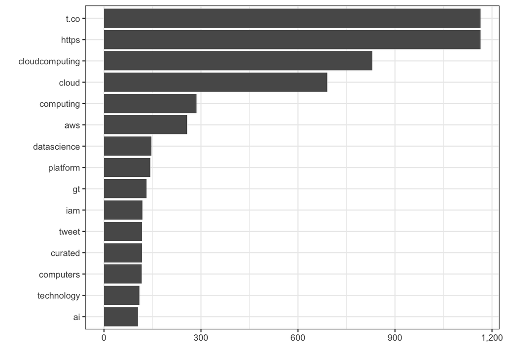

```r
library(tidytext)

cc_twts <- search_tweets("#CloudComputing ", n=1000, include_rts = FALSE)

count_df <- cc_twts %>%
  select(status_id, text) %>%
  unnest_tokens(word, text) %>%
  anti_join(stop_words, by = "word") %>%
  count(word, sort = TRUE) %>%
  top_n(15, wt=n)


count_df %>%
  ggplot(aes(x=fct_reorder(word, n), y=n)) +
    geom_col() +
    coord_flip() +
    labs(x="", y="") +
    scale_y_continuous(labels = scales::comma) +
    theme_bw()
```

[^1]: [Hootsuite, “25 Twitter Stats All Marketers Need to Know in 2020”](https://blog.hootsuite.com/twitter-statistics/)